# IPM lecture code

## Introduction

Thank you for listening to my lecture!

This file contains all you need in order to run the examples in `STAN` and to run your first integrated model. Let me know if you have any questions!

## Data and code

This example, was inspired by a similar example (and dataset) found in the following book:

Kéry, M., & Kellner, K. F. (2024). *Applied statistical modelling for ecologists: A practical guide to Bayesian and likelihood inference using R, JAGS, NIMBLE, Stan and TMB* (1st edition). Elsevier.

I highly recommend this book for any ecologist!

The dataset in the example is not real, and was obtained by simulating data. This is an ideal way to test new quantitative models because it allows you to compare your estimated to the real parameters! Here is the code I used to simulate the data:

```r
set.seed(20)

# Simulate the two data sets and plot them
# Choose sample size and parameter values for both data sets
nsites1 <- 500                                         # Sample size for count data
nsites2 <- 1000                                        # Sample size for zero-truncated counts
nsites3 <- 2000                                        # Sample size for detection/nondetection data
mean.lam <- 2                                          # Average expected abundance (lambda) per site
beta <- -2                                             # Coefficient of elevation covariate on lambda
truth <- c("log.lam" = log(mean.lam),"beta" = beta)    # Save truth

# Simulate elevation covariate for all three and standardize to mean of 1000 and
# standard deviation also of 1000 m
elev1 <- sort(runif(nsites1, 200, 2000))               # Imagine 200–2000 m a.s.l.
elev2 <- sort(runif(nsites2, 200, 2000))
elev3 <- sort(runif(nsites3, 200, 2000))
selev1 <- (elev1-1000)/1000                            # Scaled elev1
selev2 <- (elev2-1000)/1000                            # Scaled elev2
selev3 <- (elev3-1000)/1000                            # Scaled elev3

# Create three regular count data sets with log-linear effects
C1 <- rpois(nsites1, exp(log(mean.lam) + beta * selev1))
C2 <- rpois(nsites2, exp(log(mean.lam) + beta * selev2))
C3 <- rpois(nsites3, exp(log(mean.lam) + beta * selev3))

table(C1)                                              # Tabulate data set 1

# Create data set 2 (C2) by zero-truncating (discard all zeroes)
ztC2 <- C2                                             # Make a copy
ztC2 <- ztC2[ztC2 > 0]                                 # Tossing out zeroes yields zero-truncated data

table(C2); table(ztC2)                                 # tabulate both original and ZT data set

# Turn count data set 3 (C3) into detection/nondetection data (y)
y <- C3                                                # Make a copy
y[y > 1] <- 1                                          # Squash to binary

table(C3) ; table(y)                                   # tabulate both original counts and DND
```

**Be aware 🧠**

I reformatted the data following the simulation. The provided code will not result in the dataframes or csv’s provided to you.

In this document I use the data that I provided:

```r
countdata1<-read.csv("countdata1.csv")
countdata2<-read.csv("countdata2.csv")
detdata<-read.csv("detection.csv")
```

These are also the datasets I used for the examples in the presentation

## Running the models in Stan

### Model 1: GLM

The first model is a GLM. It is pretty easy to run in STAN,

This is how I would do it, but you can modify it (be aware, I am more familiar with JAGS)

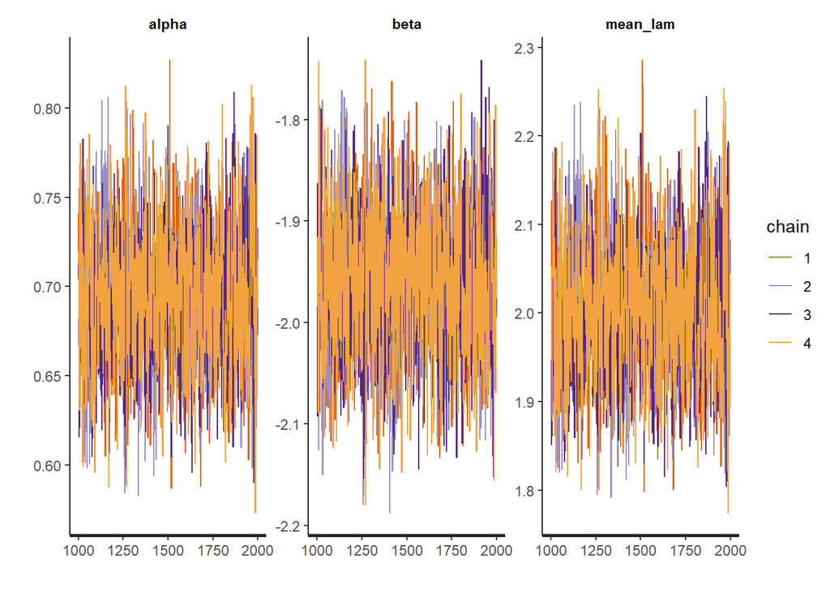

```r
library(rstan)
bdata <- list(C1 = countdata1$counts, nsites1 = nrow(countdata1), selev1 = countdata1$selev)

cat(file = "model4.stan",
    "data {
  int nsites1;
  array[nsites1] int C1;
  vector[nsites1] selev1;
}
parameters {
  real alpha;
  real beta;
}
model {
  vector[nsites1] lambda1;

  // Priors
  alpha ~ uniform(-10, 10);
  beta ~ normal(0, 100);

  // Likelihood
  for (i in 1:nsites1){
    lambda1[i] = exp(alpha + beta * selev1[i]);
    C1[i] ~ poisson(lambda1[i]);
  }

}

generated quantities {
  real mean_lam = exp(alpha);
}
" )

# Parameters monitored
params <- c("mean_lam", "alpha", "beta")

# HMC settings
ni <- 2000 ; nb <- 1000 ; nc <- 4 ; nt <- 1

# Call STAN, assess convergence and print results table
  out4.stan <- stan(file = "model4.stan", data = bdata,
                    warmup = nb, iter = ni, chains = nc, thin = nt)
rstan::traceplot(out4.stan)
```

```r
print(out4.stan, dig = 3)
```

```
Inference for Stan model: anon_model.
4 chains, each with iter=2000; warmup=1000; thin=1;
post-warmup draws per chain=1000, total post-warmup draws=4000.

            mean se_mean    sd    2.5%     25%     50%     75%   97.5% n_eff
alpha      0.694   0.001 0.038   0.621   0.668   0.695   0.719   0.769  1317
beta      -1.961   0.002 0.069  -2.095  -2.007  -1.962  -1.914  -1.822  1368
mean_lam   2.003   0.002 0.075   1.861   1.951   2.003   2.052   2.158  1315
lp__     553.158   0.029 1.007 550.370 552.779 553.454 553.885 554.158  1210
          Rhat
alpha    1.003
beta     1.002
mean_lam 1.003
lp__     1.006

Samples were drawn using NUTS(diag_e) at Thu Nov 21 00:53:23 2024.
For each parameter, n_eff is a crude measure of effective sample size,
and Rhat is the potential scale reduction factor on split chains (at
convergence, Rhat=1).
```

```r
stan_est <- summary(out4.stan)$summary[1:2,1]
```

### Model 2: Zero truncated

**How to zero-truncate?**

It is very easy to fit zero truncated models in **stan** (or JAGS).

We simply use the `T()` syntax

```r
bdata <- list(C2 = countdata2$counts, nsites2 = nrow(countdata2), selev2 = countdata2$selev)


cat(file = "model4.stan",
"data {
  int nsites2;
  array[nsites2] int C2;
  vector[nsites2] selev2;
}
parameters {
  real alpha;
  real beta;
}
model {
  vector[nsites2] lambda2;

  // Priors
  alpha ~ uniform(-10, 10);
  beta ~ normal(0, 100);

  // Likelihood

  for (j in 1:nsites2){
    lambda2[j] = exp(alpha + beta * selev2[j]);
    C2[j] ~ poisson(lambda2[j]) T[1, ];
  }

}

generated quantities {
  real mean_lam = exp(alpha);
}
" )

# Parameters monitored
params <- c("mean_lam", "alpha", "beta")

# HMC settings
ni <- 2000 ; nb <- 1000 ; nc <- 4 ; nt <- 1

# Call STAN , assess convergence and print results table
system.time(
  out4.stan <- stan(file = "model4.stan", data = bdata,
    warmup = nb, iter = ni, chains = nc, thin = nt) )
```

```
   user  system elapsed
  16.31    0.08   57.53
```

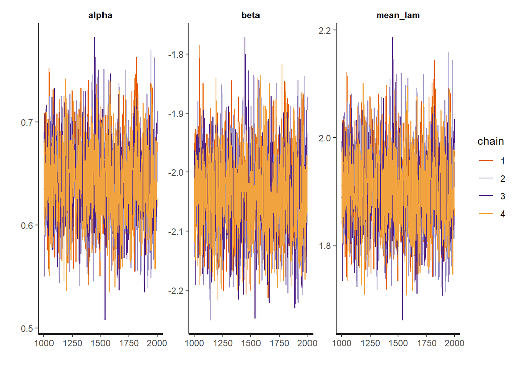

```r
rstan::traceplot(out4.stan)
```

```r
print(out4.stan, dig = 3)
```

```
Inference for Stan model: anon_model.
4 chains, each with iter=2000; warmup=1000; thin=1;
post-warmup draws per chain=1000, total post-warmup draws=4000.

             mean se_mean    sd     2.5%      25%      50%      75%    97.5%
alpha       0.644   0.001 0.039    0.567    0.618    0.643    0.670    0.720
beta       -2.038   0.002 0.071   -2.174   -2.086   -2.038   -1.991   -1.894
mean_lam    1.905   0.002 0.074    1.763    1.855    1.903    1.953    2.054
lp__     1418.915   0.027 0.992 1416.411 1418.509 1419.224 1419.634 1419.898
         n_eff  Rhat
alpha     1243 1.000
beta      1321 1.000
mean_lam  1239 1.000
lp__      1357 1.001

Samples were drawn using NUTS(diag_e) at Thu Nov 21 00:54:22 2024.
For each parameter, n_eff is a crude measure of effective sample size,
and Rhat is the potential scale reduction factor on split chains (at
convergence, Rhat=1).
```

```r
stan_est <- summary(out4.stan)$summary[1:2,1]
```

### Model 3: cloglog bernoulli

```r
bdata <- list(y = detdata$y, nsites3 = nrow(detdata), selev3 = detdata$selev)

cat(file = "model4.stan",
"data {

  int nsites3;

  array[nsites3] int y;

  vector[nsites3] selev3;
}
parameters {
  real alpha;
  real beta;
}
model {

  vector[nsites3] psi;

  // Priors
  alpha ~ uniform(-10, 10);
  beta ~ normal(0, 100);

  // Likelihood

  for (k in 1:nsites3){
    psi[k] = inv_cloglog(alpha + beta * selev3[k]);
    y[k] ~ bernoulli(psi[k]);
  }
}

generated quantities {
  real mean_lam = exp(alpha);
}
" )

# Parameters monitored
params <- c("mean_lam", "alpha", "beta")

# HMC settings
ni <- 2000 ; nb <- 1000 ; nc <- 4 ; nt <- 1

# Call STAN (ART 90/45 sec), assess convergence and print results table
system.time(
  out4.stan <- stan(file = "model4.stan", data = bdata,
    warmup = nb, iter = ni, chains = nc, thin = nt) )
```

```
   user  system elapsed
  27.42    0.05   68.25
```

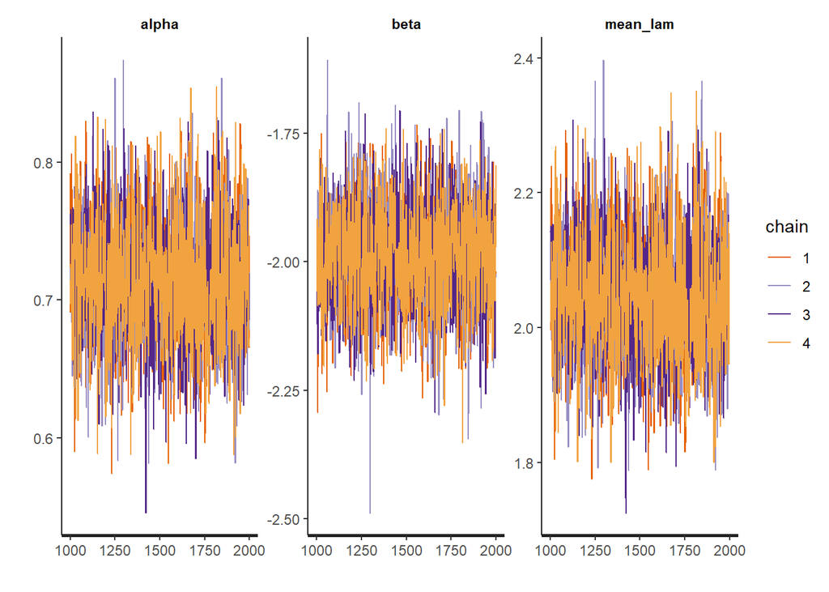

```r
rstan::traceplot(out4.stan)
```

```r
print(out4.stan, dig = 3)
```

```
Inference for Stan model: anon_model.
4 chains, each with iter=2000; warmup=1000; thin=1;
post-warmup draws per chain=1000, total post-warmup draws=4000.

             mean se_mean    sd     2.5%      25%      50%      75%    97.5%
alpha       0.714   0.001 0.043    0.632    0.684    0.713    0.743    0.799
beta       -1.990   0.002 0.097   -2.183   -2.055   -1.992   -1.923   -1.798
mean_lam    2.043   0.002 0.088    1.882    1.981    2.040    2.101    2.223
lp__     -785.936   0.026 1.053 -788.732 -786.341 -785.609 -785.200 -784.932
         n_eff  Rhat
alpha     1636 1.000
beta      1826 0.999
mean_lam  1627 1.000
lp__      1655 1.001

Samples were drawn using NUTS(diag_e) at Thu Nov 21 00:55:31 2024.
For each parameter, n_eff is a crude measure of effective sample size,
and Rhat is the potential scale reduction factor on split chains (at
convergence, Rhat=1).
```

```r
stan_est <- summary(out4.stan)$summary[1:2,1]
```

**Challenge**

Run a single integrated model using the three datasets

## Other code used in slideshow

Here is all the code used in the slideshow, in case you find it useful:

```r
library(ggplot2)
library(cowplot)
countdata1<-read.csv("countdata1.csv")
countdata2<-read.csv("countdata2.csv")
detdata<-read.csv("detection.csv")

ggplot(data=countdata1, aes(x=elevation, y=counts))+
geom_point()+
  geom_smooth(method = glm, method.args = list(family = "poisson"))+
  xlab("Elevation (m)")+
  ylab("Counts")+

  theme_cowplot()
```

```r
summary(fm1 <- glm(counts ~ selev, data= countdata1, family = poisson(link = "log")))
```

```r
library(ASMbook)
NLL1 <- function(param, y, x) {
  alpha <- param[1]
  beta <- param[2]
  lambda <- exp(alpha + beta * x)
  LL <- dpois(y, lambda, log = TRUE)                   # LL contribution for each datum
  return(-sum(LL))                                     # NLL for all data
}

# Minimize NLL
inits <- c(alpha = 0, beta = 0)                        # Need to provide initial values
sol1 <- optim(inits, NLL1, y = countdata1$counts, x = countdata1$selev, hessian = TRUE, method = 'BFGS')
tmp1 <- get_MLE(sol1, 4)
```

```r
NLL2 <- function(param, y, x) {
  alpha <- param[1]
  beta <- param[2]
  lambda <- exp(alpha + beta * x)
  L <- dpois(y, lambda)/(1-ppois(0, lambda))           # L. contribution for each datum
  return(-sum(log(L)))                                 # NLL for all data
}

# Minimize NLL
inits <- c(alpha = 0, beta = 0)                        # Need to provide initial values
sol2 <- optim(inits, NLL2, y = countdata2$counts, x = countdata2$selev, hessian = TRUE, method = 'BFGS')
tmp2 <- get_MLE(sol2, 4)
```

```r
summary(fm3 <- glm(y ~ selev,data=detdata, family = binomial(link = "cloglog")))
```

```r
NLL3 <- function(param, y, x) {
  alpha <- param[1]
  beta <- param[2]
  lambda <- exp(alpha + beta * x)
  psi <- 1-exp(-lambda)
  LL <- dbinom(y, 1, psi, log = TRUE)                  # L. contribution for each datum
  return(-sum(LL))                                     # NLL for all data
}

# Minimize NLL
inits <- c(alpha = 0, beta = 0)
sol3 <- optim(inits, NLL3, y = y, x = selev3, hessian = TRUE, method = 'BFGS')
tmp3 <- get_MLE(sol3, 4)
```

```r
NLLjoint <- function(param, y1, x1, y2, x2, y3, x3) {
  # Definition of elements in param vector (shared between data sets)
  alpha <- param[1]                                    # log-linear intercept
  beta <- param[2]                                     # log-linear slope
  # Likelihood for the Poisson GLM for data set 1 (y1, x1)
  lambda1 <- exp(alpha + beta * x1)
  L1 <- dpois(y1, lambda1)
  # Likelihood for the ztPoisson GLM for data set 2 (y2, x2)
  lambda2 <- exp(alpha + beta * x2)
  L2 <- dpois(y2, lambda2)/(1-ppois(0, lambda2))
  # Likelihood for the cloglog Bernoulli GLM for data set 3 (y3, x3)
  lambda3 <- exp(alpha + beta * x3)
  psi <- 1-exp(-lambda3)
  L3 <- dbinom(y3, 1, psi)
  # Joint log-likelihood and joint NLL: here you can see that sum!
  JointLL <- sum(log(L1)) + sum(log(L2)) + sum(log(L3)) # Joint LL
  return(-JointLL)                                      # Return joint NLL
}

# Minimize NLLjoint
inits <- c(alpha = 0, beta = 0)
solJoint <- optim(inits, NLLjoint, y1 = countdata1$counts, x1 = countdata1$selev, y2 = countdata2$counts, x2 = countdata2$selev,
  y3 =detdata$y, x3 = detdata$selev, hessian = TRUE, method = 'BFGS')

# Get MLE and asymptotic SE and print and save
(tmp4 <- get_MLE(solJoint, 4))
diy_est <- tmp4[,1]
```